# newnewnew.proj4

```r
subset1<-subset1 %>% rename_all(function(.name){.name %>% tolower})
```

```r
subset1<-subset1 %>%
  drop_na() %>%
  mutate_all(as.factor) %>%
  mutate(tenure=as.numeric(tenure),
         monthlycharges=as.numeric(monthlycharges))
```

```r
colSums(sapply(subset1, is.na))
```

```
##         gender  seniorcitizen        partner     dependents         tenure
##              0              0              0              0              0
## monthlycharges       contract          churn
##              0              0              0
```

```r
str(subset1)
```

```
## 'data.frame':    7043 obs. of  8 variables:
##  $ gender        : Factor w/ 2 levels "Female","Male": 1 2 2 2 1 1 2 1 1 2 ...
##  $ seniorcitizen : Factor w/ 2 levels "0","1": 1 1 1 1 1 1 1 1 1 1 ...
##  $ partner       : Factor w/ 2 levels "No","Yes": 2 1 1 1 1 1 1 1 2 1 ...
##  $ dependents    : Factor w/ 2 levels "No","Yes": 1 1 1 1 1 1 2 1 1 2 ...
##  $ tenure        : num  2 35 3 46 3 9 23 11 29 63 ...
##  $ monthlycharges: num  143 499 437 267 730 ...
##  $ contract      : Factor w/ 3 levels "Month-to-month",..: 1 2 1 2 1 1 1 1 1 2 ...
##  $ churn         : Factor w/ 2 levels "No","Yes": 1 1 2 1 2 2 1 1 2 1 ...
```

We have worked on the “Churn” data set several times this semester: building both decision tree, regression tree, and random forest models to predict whether people churn or not. In this project, we will try the K Nearest Neighbor model on it. Recall that the “Churn” variable is a binary categorical variable showing whether a customer has “churned” or not. “Churn” means terminating the subscription or leaving the company.Please include the following variables in your subset: gender, SeniorCitizen, Partner Dependents, tenure, MonthlyCharges, Contract, Churn.Before you start estimating KNN models, please make sure you code all variables properly (ex. all character variables into factors.)KNN requires that all factors be coded into numeric dummy variables. Please include the following segment “step_dummy(all_nominal(), -all_outcomes())”as one of the pre-processing steps (when creating recipe). This step codes all factors into dummy variables (a k-category variable is coded into k-1 dummies) except the target.

1.Build a tuning procedure for the hyperparameter of K using “tidymodels.” Please make sure you include all the following steps:

a.) split data into training and testing sets (70%-30% split),

```r
set.seed(123)
subset.split<-initial_split(subset1, prop=.7, strata = churn)
subset.train<-training(subset.split)
subset.test<-testing(subset.split)
```

b.) specify a re-sampling procedure (10-fold cross-validation),

```r
# split training set 90|10
k_fold<-vfold_cv(subset.train)
```

c.) create a recipe and preprocessing steps,

```r
model.rec<-recipe(churn~., subset.train) %>% step_range(all_numeric()) %>% step_dummy(all_nominal(),-all_outcomes())

model.rec %>% prep() %>% juice() %>% summary()
```

```
##      tenure       monthlycharges   churn       gender_Male     seniorcitizen_X1
##  Min.   :0.0000   Min.   :0.0000   No :3622   Min.   :0.0000   Min.   :0.0000
##  1st Qu.:0.1250   1st Qu.:0.1292   Yes:1309   1st Qu.:0.0000   1st Qu.:0.0000
##  Median :0.4028   Median :0.4555              Median :1.0000   Median :0.0000
##  Mean   :0.4508   Mean   :0.4327              Mean   :0.5013   Mean   :0.1659
##  3rd Qu.:0.7639   3rd Qu.:0.6879              3rd Qu.:1.0000   3rd Qu.:0.0000
##  Max.   :1.0000   Max.   :1.0000              Max.   :1.0000   Max.   :1.0000
##   partner_Yes     dependents_Yes   contract_One.year contract_Two.year
##  Min.   :0.0000   Min.   :0.0000   Min.   :0.0000    Min.   :0.0000
##  1st Qu.:0.0000   1st Qu.:0.0000   1st Qu.:0.0000    1st Qu.:0.0000
##  Median :0.0000   Median :0.0000   Median :0.0000    Median :0.0000
##  Mean   :0.4788   Mean   :0.2999   Mean   :0.2071    Mean   :0.2387
##  3rd Qu.:1.0000   3rd Qu.:1.0000   3rd Qu.:0.0000    3rd Qu.:0.0000
##  Max.   :1.0000   Max.   :1.0000   Max.   :1.0000    Max.   :1.0000
```

d.) specify the metrics you eventually need (make sure you include accuracy, sensitivity, specificity, and roc_auc),

```r
# sens - out of all the positive classes how many were correctly predicted
#specs- out of all the negative classes how many were correctly predicted
c.metrics<-yardstick::metric_set(accuracy,
                      sens,
                      roc_auc,
                      )
```

e.) save the predicted value using model control grid, and

```r
m_control<-control_grid(save_pred=TRUE)
```

f.) set the mode and engine for the tuning process. Please place your code in order and explain each segment using a hashtag if necessary. (To make sure that your results are reproducible, you need to set the random seeds consistently at each random step)

```r
set.seed(123)
knn_model<-nearest_neighbor(neighbors= tune("K")) %>%
  set_mode("classification") %>%
  set_engine("kknn")
```

```r
knn_grid<- grid_regular(parameters(knn_model), levels=5)
```

2.Tune K in a KNN model and obtain plots for all mean metrics. Which metric(s) shows a clear pattern when K increases, which does not if any? What is the best K if you are to base your decision on the mean “accuracy” or “roc_auc” alone?

```r
set.seed(123)
knn.tune<-tune_grid(
  knn_model,
  model.rec,
  resamples=k_fold,
  control=m_control,
  metrics=c.metrics
  )
```

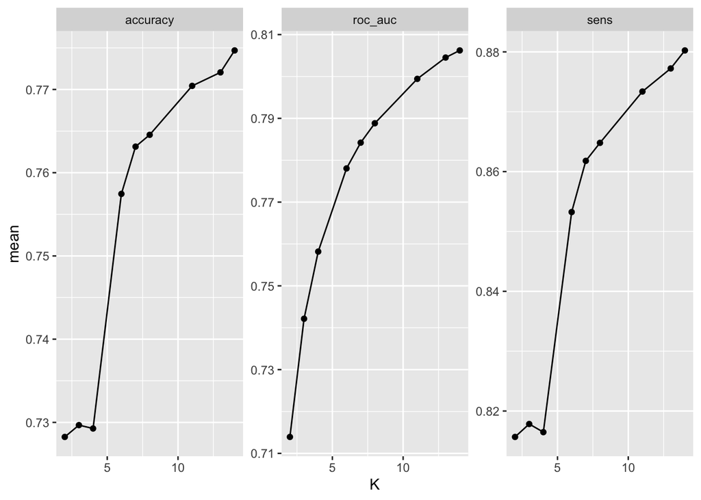

TRUE

```r
set.seed(123)
knn.tune %>%
  collect_metrics() %>%
  ggplot(aes(x=K,y=mean))+
  geom_point()+
  geom_line()+
  facet_wrap(~.metric, scales="free_y")
```